# Academic Advising Simulator Project

TJ Schaeffer

Due: 03/31/2019

# Project tasks

*Many academic departments have walk-in academic advising during busy periods in the semester (e.g., Drop/Add week). The Department of Statistics currently has one academic advisor on staff. We are interested in using simulation to understand how long students are likely to wait for walk-in advising during these busy periods. Furthermore, the head of the statistics department would like to understand the potential impact if it were possible to hire a second advisor to assist during those periods.*

# Part 1. Bank teller simulation.

*In programming, it’s often a good idea to start with some working code that accomplishes a similar task, and then make small modifications until we have accomplished our goal. We will adopt this philosophy and begin with a working example from the Bank Teller simulation discussed in class.*

**Task 1.1 Reproduce the Bank Teller simulation here exactly as it is described in your MDSR textbook (p. 232 & 233).**

```r
any_active <- function(df) { # return TRUE if someone has not finished
  return(max(df$endtime) == Inf)
}
next_customer <- function(df) { # returns the next customer in line
  res <- filter(df, endtime == Inf) %>%
arrange(arrival)
  return(head(res, 1))
}
update_customer <- function(df, cust_num, end_time) { # sets the end time of a specific customer
  return(mutate(df, endtime =
                  ifelse(custnum == cust_num, end_time, endtime)))
}
run_sim <- function(n = 1/2, m = 3/2, hours = 6) {
  # simulation of bank where there is just one teller
  # n: expected number of customers per minute
  # m: expected length of transaction is m minutes
  # hours: bank open for this many hours
  customers <- rpois(hours * 60, lambda = n)
  arrival <- numeric(sum(customers))
  position <- 1
  for (i in 1:length(customers)) {
    numcust <- customers[i]
    if (numcust != 0) {
      arrival[position:(position + numcust - 1)] <- rep(i, numcust)
      position <- position + numcust
    }
  }
  duration <- rexp(length(arrival), rate = 1/m) # E[X]=m
  df <- data.frame(arrival, duration, custnum = 1:length(duration),
                 endtime = Inf, stringsAsFactors = FALSE)

  endtime <- 0 # set up beginning of simulation
  while (any_active(df)) { # anyone left to serve?
    next_one <- next_customer(df)
    now <- ifelse(next_one$arrival >= endtime, next_one$arrival, endtime)
    endtime <- now + next_one$duration
    df <- update_customer(df, next_one$custnum, endtime)
  }
  df <- mutate(df, totaltime = endtime - arrival)
  return(favstats(~ totaltime, data = df))
}
sim_results <- do(3) * run_sim()
sim_results
```

| min | Q1 | median | Q3 | max | mean | sd | n | missing | .row | .index |
| --- | --- | --- | --- | --- | --- | --- | --- | --- | --- | --- |
| 0.091980040 | 4.846057 | 12.852299 | 21.916730 | 39.39118 | 13.967632 | 10.151263 | 195 | 0 | 1 | 1 |
| 0.008157466 | 1.356412 | 2.825231 | 4.858877 | 12.44368 | 3.486456 | 2.688653 | 169 | 0 | 1 | 2 |
| 0.009380345 | 2.577422 | 5.917604 | 11.411510 | 20.72558 | 7.238739 | 5.641269 | 170 | 0 | 1 | 3 |

```
  for (i in 1:length(customers)) {
    numcust <- customers[i]
    if (numcust != 0) {
      arrival[position:(position + numcust - 1)] <- rep(i, numcust)
      position <- position + numcust
    }
  }
```

**Task 1.3 Use `mosaic::do()` to repeat the simulation at least 20 times, and then store the summary statistics of `totaltime` from each run of your Bank Teller simulation. (Note: don’t be surprised if you have to wait at least 20-30 seconds, depending on your computer)**

```r
sim_results2 <- mosaic::do(20) * run_sim()
```

**Task 1.4 Show the summary statistics corresponding to the 6 iterations of your Bank Teller simulation with the longest MAXIMUM wait time of any customer.**

```r
sim_results2 %>%
  arrange(desc(max)) %>%
  head(6)
```

|  | min | Q1 | median | Q3 | max | mean | sd | n | missing | .row | .index |
| --- | --- | --- | --- | --- | --- | --- | --- | --- | --- | --- | --- |
| 1 | 0.129332257 | 2.382249 | 6.037828 | 23.600438 | 35.94905 | 11.330941 | 11.420111 | 178 | 0 | 1 | 2 |
| 2 | 0.066052253 | 2.583903 | 6.864868 | 20.790249 | 33.87803 | 11.950790 | 10.177474 | 175 | 0 | 1 | 8 |
| 3 | 0.693017269 | 3.898288 | 8.462027 | 20.433157 | 32.67611 | 11.684727 | 8.865281 | 206 | 0 | 1 | 6 |
| 4 | 0.034722922 | 1.371712 | 3.978697 | 8.270183 | 25.65503 | 5.698590 | 5.859069 | 171 | 0 | 1 | 18 |
| 5 | 0.006128957 | 1.507553 | 4.263316 | 7.784357 | 25.39518 | 6.044409 | 6.049831 | 195 | 0 | 1 | 13 |
| 6 | 0.060128113 | 2.504528 | 5.551022 | 10.531782 | 23.45055 | 6.928689 | 5.657637 | 177 | 0 | 1 | 3 |

**Task 1.5 Show the summary statistics corresponding to the 6 iterations of your Bank Teller simulation with the longest average wait time.**

```r
sim_results2 %>%
  arrange(desc(mean)) %>%
  head(6)
```

|  | min | Q1 | median | Q3 | max | mean | sd | n | missing | .row | .index |
| --- | --- | --- | --- | --- | --- | --- | --- | --- | --- | --- | --- |
| 1 | 0.06605225 | 2.583903 | 6.864868 | 20.790249 | 33.87803 | 11.950790 | 10.177474 | 175 | 0 | 1 | 8 |
| 2 | 0.69301727 | 3.898288 | 8.462027 | 20.433157 | 32.67611 | 11.684727 | 8.865281 | 206 | 0 | 1 | 6 |
| 3 | 0.12933226 | 2.382249 | 6.037828 | 23.600438 | 35.94905 | 11.330941 | 11.420111 | 178 | 0 | 1 | 2 |
| 4 | 0.06012811 | 2.504528 | 5.551022 | 10.531782 | 23.45055 | 6.928689 | 5.657637 | 177 | 0 | 1 | 3 |
| 5 | 0.02113685 | 1.227857 | 3.166401 | 13.916831 | 21.68444 | 6.523866 | 6.910857 | 169 | 0 | 1 | 17 |
| 6 | 0.03386269 | 2.038836 | 4.049995 | 9.743989 | 19.99221 | 6.357381 | 5.631325 | 189 | 0 | 1 | 12 |

**Task 1.6 Use the following `arrival` and `duration` data to verify the outcome shown as evidence that your teller simulation code works properly:**

- **`arrival <- c(1, 3, 7, 10, 11, 15)`**
- **`duration <- c(3, 2, 5, 6, 8, 1)`**
- **Outcome: show that your approach results in `totaltime` of 3, 3, 5, 8, 15, and 12 respectively**
- **Note: the previous bank teller simulation both simulates customers AND the teller who serves them. Just extract the “teller” portion of the code to verify that it is working properly, and then show `totaltime` directly.**

```r
arrival <- c(1, 3, 7, 10, 11, 15)
duration <- c(3, 2, 5, 6, 8, 1)
df <- data.frame(arrival, duration, custnum = 1:length(duration),
                 endtime = Inf, stringsAsFactors = FALSE)
endtime <- 0 # set up beginning of simulation
  while (any_active(df)) { # anyone left to serve?
    next_one <- next_customer(df)
    now <- ifelse(next_one$arrival >= endtime, next_one$arrival, endtime)
    endtime <- now + next_one$duration
    df <- update_customer(df, next_one$custnum, endtime)
  }
 df <- mutate(df, totaltime = endtime - arrival)
 df$totaltime
```

```
[1]  3  3  5  8 15 12
```

# Part 2. Academic advisor simulation

*Now that you are confident that your Bank Teller simulation is working properly, we will modify it to simulate the context of academic advising as described previously.*

**Task 2.2 Show how you would modify the teller simulation to simulate an academic advisor under the following conditions:**

- **6.5 hours of walk-in advising each day during Drop/Add week;**
- **we expect one a new student to arrive every 12 minutes, on average;**
- **we expect each of the walk-in advising appointments to last about 10 minutes on average.**

```r
any_active <- function(df) { # return TRUE if someone has not finished
  return(max(df$endtime) == Inf)
}
next_student <- function(df) { # returns the next student in line
  res <- filter(df, endtime == Inf) %>%
arrange(arrival)
  return(head(res, 1))
}
update_student <- function(df, stud_num, end_time) { # sets the end time of a specific student
  return(mutate(df, endtime =
                  ifelse(studnum == stud_num, end_time, endtime)))
}
run_stud <- function(n = 1/12, m = 10, hours = 6.5) {
  # simulation of bank where there is just one advisor
  # n: expected number of students per minute
  # m: expected length of transaction is m minutes
  # hours: bank open for this many hours
  students <- rpois(hours * 60, lambda = n)
  arrival <- numeric(sum(students))
  position <- 1
  for (i in 1:length(students)) {
    numstud <- students[i]
    if (numstud != 0) {
      arrival[position:(position + numstud - 1)] <- rep(i, numstud)
      position <- position + numstud
    }
  }
  duration <- rexp(length(arrival), rate = 1/m) # E[X]=m
  df <- data.frame(arrival, duration, studnum = 1:length(duration),
                 endtime = Inf, stringsAsFactors = FALSE)

  endtime <- 0 # set up beginning of simulation
  while (any_active(df)) { # anyone left to serve?
    next_one <- next_student(df)
    now <- ifelse(next_one$arrival >= endtime, next_one$arrival, endtime)
    endtime <- now + next_one$duration
    df <- update_student(df, next_one$studnum, endtime)
  }
  df <- mutate(df, totaltime = endtime - arrival)
  return(favstats(~ totaltime, data = df))
}
stud_results <- do(3) * run_stud()
stud_results
```

| min | Q1 | median | Q3 | max | mean | sd | n | missing | .row | .index |
| --- | --- | --- | --- | --- | --- | --- | --- | --- | --- | --- |
| 0.09381749 | 8.390119 | 26.19210 | 40.51925 | 118.21101 | 32.80567 | 33.88841 | 38 | 0 | 1 | 1 |
| 0.78369458 | 12.454550 | 28.13691 | 39.07421 | 73.14403 | 28.87204 | 18.76803 | 33 | 0 | 1 | 2 |
| 0.53735822 | 5.700007 | 27.99178 | 42.34197 | 59.37249 | 26.52381 | 20.93781 | 24 | 0 | 1 | 3 |

**Task 2.3 Use the following `arrival` and `duration` data to verify the outcome shown as evidence that your academic advisor simulation code works properly:**

- **`arrival <- c(7, 42, 49, 54, 55)`**
- **`duration <- c(20, 11, 15, 31, 7)`**
- **Outcome: show that your approach results in `totaltime` of 20, 11, 19, 45, and 51 respectively**

```r
arrival <- c(7, 42, 49, 54, 55)
duration <- c(20, 11, 15, 31, 7)
  df2 <- data.frame(arrival, duration, studnum = 1:length(duration),
                 endtime = Inf, stringsAsFactors = FALSE)
endtime <- 0 # set up beginning of simulation
  while (any_active(df2)) { # anyone left to serve?
    next_one <- next_student(df2)
    now <- ifelse(next_one$arrival >= endtime, next_one$arrival, endtime)
    endtime <- now + next_one$duration
    df2 <- update_student(df2, next_one$studnum, endtime)
  }
  df2 <- mutate(df2, totaltime = endtime - arrival)
  df2$totaltime
```

```
[1] 20 11 19 45 51
```

**Task 2.4 Use `mosaic::do()` to repeat the simulation at least 20 times, and then store the summary statistics of `totaltime` from each run of your walk-in advising simulation. (Note: don’t be surprised if you have to wait at least 20-30 seconds, depending on your computer)**

```r
stud_results2 <- mosaic::do(80) * run_stud()
```

**Task 2.5 Show the summary statistics corresponding to the 6 iterations of your walk-in advising simulation in which the advisor served the MOST STUDENTS in a day (i.e., 6.5 hour period).**

```r
stud_results2 %>%
  arrange(desc(n)) %>%
  head(6)
```

|  | min | Q1 | median | Q3 | max | mean | sd | n | missing | .row | .index |
| --- | --- | --- | --- | --- | --- | --- | --- | --- | --- | --- | --- |
| 1 | 3.0172487 | 19.24658 | 34.64123 | 50.51200 | 106.91584 | 39.57017 | 28.28139 | 49 | 0 | 1 | 46 |
| 2 | 13.3032534 | 50.71965 | 62.35183 | 66.76666 | 77.85381 | 56.58101 | 14.65072 | 45 | 0 | 1 | 13 |
| 3 | 1.0879320 | 45.80977 | 65.02354 | 111.78823 | 149.93737 | 76.54969 | 39.11168 | 42 | 0 | 1 | 3 |
| 4 | 2.2355762 | 17.70122 | 62.96626 | 75.67573 | 98.77934 | 53.01983 | 29.94807 | 42 | 0 | 1 | 41 |
| 5 | 0.1798926 | 15.04626 | 25.89954 | 45.07616 | 97.27532 | 31.04686 | 24.48241 | 42 | 0 | 1 | 79 |
| 6 | 1.5697439 | 64.43721 | 89.79036 | 124.83133 | 161.07368 | 87.43306 | 45.04279 | 41 | 0 | 1 | 27 |

**Task 2.6 Show a density plot of the third quartile of `totaltime` among simulated walk-in advising shifts. Add a “rug plot” to show the actual simulated outcomes observed in the margin of your plot. Be sure to use good plotting practices.**

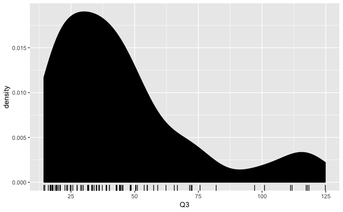

```r
stud_results2 %>%
  ggplot(aes(x = Q3)) +
  geom_density(fill = 'black') +
  geom_rug()
```

# Part 3. Adding a second advisor.

*Now that we understand the simulation and have translated it to the context of walk-in academic advising, we want to study the impact of adding a second walk-in advisor during busy periods like Drop/Add week at the beginning of the semester.*

**Task 3.1 You will need to modify the code from Part 2 in order to introduce a second academic advisor. Use the following `arrival` and `duration` data to verify the outcome shown as evidence that you have successfully implemented a second academic advisor helping students in parallel on a first-come, first-served basis:**

- **`arrival <- c(7, 42, 49, 54, 55)`**
- **`duration <- c(20, 11, 15, 31, 7)`**
- **Outcome: show that your approach results in `totaltime` of 20, 11, 15, 31, and 16, respectively**

```r
arrival <- c(7, 42, 49, 54, 55)
duration <- c(20, 11, 15, 31, 7)
df3 <- data.frame(arrival, duration, studnum = 1:length(duration),
                 endtime = Inf, stringsAsFactors = FALSE)
endtime1 <- 0
endtime2 <- 0 # set up beginning of simulation
  while (any_active(df3)) {# anyone left to serve?
    next_one <- next_student(df3)
    if (next_one$arrival >= endtime1) {
      endtime1 <- next_one$arrival + next_one$duration
      df3 <- update_student(df3, next_one$studnum, endtime1)
    }
    else if(next_one$arrival < endtime1 & next_one$arrival >= endtime2) {
    endtime2 <- next_one$arrival + next_one$duration
    df3 <- update_student(df3, next_one$studnum, endtime2)
  } else {
    endtime3 <- min(endtime1, endtime2) + next_one$duration
    df3 <- update_student(df3, next_one$studnum, endtime3)
  }
}
df3 <- mutate(df3, totaltime = endtime - arrival)
df3$totaltime
```

```
[1] 20 11 15 31 16
```

**Task 3.2 Breifly describe a bullet list of the changes that you made in order to incorporate a second academic advisor.** * Changed data frame * Added a second endtime to represent the wait time with the second advisor * Added a if/else statement to represent total time

**Task 3.3 Use `mosaic::do()` to repeat the simulation at least 20 times, and then store the summary statistics of `totaltime` from each run of your walk-in advising simulation with TWO academic advisors helping students in parallel on a first-come, first-served basis.**

```r
# Repeated code needed for 3.3
any_active <- function(df3) { # return TRUE if someone has not finished
  return(max(df3$endtime) == Inf)
}
next_student <- function(df3) { # returns the next student in line
  res <- filter(df3, endtime == Inf) %>%
arrange(arrival)
  return(head(res, 1))
}
update_student <- function(df3, stud_num, end_time) { # sets the end time of a specific student
  return(mutate(df3, endtime =
                  ifelse(studnum == stud_num, end_time, endtime)))
}
run_stud2 <- function(n = 1/12, m = 10, hours = 6.5) {
  students <- rpois(hours * 60, lambda = n)
  arrival <- numeric(sum(students))
  position <- 1
  for (i in 1:length(students)) {
    numstud <- students[i]
    if (numstud != 0) {
      arrival[position:(position + numstud - 1)] <- rep(i, numstud)
      position <- position + numstud
    }
  }
  duration <- rexp(length(arrival), rate = 1/m) # E[X]=m
  df3 <- data.frame(arrival, duration, studnum = 1:length(duration),
                 endtime = Inf, stringsAsFactors = FALSE)
  endtime1 <- 0
  endtime2 <- 0 # set up beginning of simulation
  while (any_active(df3)) {# anyone left to serve?
    next_one <- next_student(df3)
    if (next_one$arrival >= endtime1) {
      endtime1 <- next_one$arrival + next_one$duration
      df3 <- update_student(df3, next_one$studnum, endtime1)
    }
    else if(next_one$arrival < endtime1 & next_one$arrival >= endtime2) {
    endtime2 <- next_one$arrival + next_one$duration
    df3 <- update_student(df3, next_one$studnum, endtime2)
  } else {
    endtime3 <- min(endtime1, endtime2) + next_one$duration
    df3 <- update_student(df3, next_one$studnum, endtime3)
    }
  }
  df3 <- mutate(df3, totaltime = endtime - arrival)
  return(favstats(~ totaltime, data = df3))
}
stud_results3 <- do(80) * run_stud2()
stud_results3
```

| min | Q1 | median | Q3 | max | mean | sd | n | missing | .row | .index |
| --- | --- | --- | --- | --- | --- | --- | --- | --- | --- | --- |
| 0.089137352 | 1.208508 | 4.443940 | 11.902284 | 19.63071 | 6.769299 | 6.707585 | 22 | 0 | 1 | 1 |
| 0.526862127 | 4.404024 | 9.876877 | 14.211851 | 47.61152 | 11.738750 | 10.667166 | 24 | 0 | 1 | 2 |
| 0.481456035 | 4.917198 | 6.484512 | 11.134908 | 17.75804 | 7.838289 | 5.114545 | 22 | 0 | 1 | 3 |
| 0.120482718 | 4.913663 | 8.321879 | 17.696965 | 44.75970 | 12.343371 | 10.432174 | 45 | 0 | 1 | 4 |
| 0.297037956 | 3.529960 | 9.551606 | 13.553204 | 50.98376 | 12.034922 | 12.706553 | 28 | 0 | 1 | 5 |
| 0.091892048 | 3.520177 | 6.107828 | 10.882847 | 39.86900 | 8.612913 | 8.730935 | 38 | 0 | 1 | 6 |
| 0.086313804 | 3.527643 | 11.220133 | 19.233613 | 67.28909 | 16.138626 | 18.606815 | 28 | 0 | 1 | 7 |
| 0.051561119 | 1.525778 | 5.878709 | 14.246072 | 27.87410 | 8.469603 | 7.676873 | 33 | 0 | 1 | 8 |
| 0.456940103 | 2.058285 | 4.585262 | 10.306367 | 37.67627 | 7.746494 | 7.864233 | 32 | 0 | 1 | 9 |
| 0.005990155 | 2.701213 | 6.732819 | 14.632022 | 32.84790 | 9.524025 | 8.715911 | 32 | 0 | 1 | 10 |

[output cut: 70 more lines]

**Task 3.4 Show the summary statistics corresponding to the 6 iterations of your walk-in advising simulation in which the TWO advisors served the MOST STUDENTS in a day (i.e., 6.5 hour period).**

```r
stud_results3 %>%
  arrange(desc(n)) %>%
  head(6)
```

|  | min | Q1 | median | Q3 | max | mean | sd | n | missing | .row | .index |
| --- | --- | --- | --- | --- | --- | --- | --- | --- | --- | --- | --- |
| 1 | 0.1204827 | 4.913663 | 8.321879 | 17.69696 | 44.75970 | 12.343371 | 10.432174 | 45 | 0 | 1 | 4 |
| 2 | 1.0299529 | 4.088988 | 11.526626 | 15.88945 | 40.41242 | 11.962778 | 9.565379 | 45 | 0 | 1 | 77 |
| 3 | 1.0642898 | 4.486774 | 9.168486 | 13.99399 | 34.50916 | 11.551781 | 9.808177 | 44 | 0 | 1 | 54 |
| 4 | 0.3357787 | 2.758275 | 5.539320 | 12.26147 | 42.51349 | 10.328971 | 10.908054 | 44 | 0 | 1 | 73 |
| 5 | 0.7364476 | 2.812967 | 5.567736 | 11.46221 | 31.44877 | 8.150751 | 7.210363 | 42 | 0 | 1 | 52 |
| 6 | 0.2684441 | 2.804076 | 6.655293 | 13.43553 | 29.08337 | 8.705857 | 7.709336 | 41 | 0 | 1 | 62 |

**Task 3.5 Show a density plot of the third quartile of `totaltime` among simulated walk-in advising shifts with TWO academic advisors working in parallel. Add a “rug plot” to show the actual simulated outcomes observed in the margin of your plot. Be sure to use good plotting practices.**

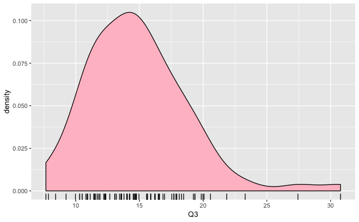

```r
stud_results3 %>%
  ggplot(aes(x = Q3)) +
  geom_density(fill = 'pink') +
  geom_rug()
```

# Part 4. Observations

**Task 4.1 Use the following information to update the number of simulations in your study above. No need to show results here, the updated simulation quantity above is sufficient.**

*Before sharing observations… it would be helpful to have a LOT more than 20 simulations. A few simple commands can be used like a timer in order to predict how long it will take you to run your simulations. For example, you could do a “small” one that takes a few seconds like we did earlier and then repeat a couple times for slightly larger volume of simulations (e.g., 40 & 80). Now you have three data points which will (hopefully) verify that the time required increasing more or less linearly. Now you can extrapolate how many simulations you want to run in some amount of time… 15 minutes? an hour?? more??? If you intend to cite specific simulation results when you share observations below, make sure you use `set.seed` appropriately in your project.*

```r
# calculate computing time for 20 sims
ptm <- Sys.time()
testing <- two_advisor_results <- mosaic::do(20) * run_stud2()
Sys.time() - ptm
```

```
Time difference of 2.288829 secs
```

```r
# calculate computing time for 40 sims
ptm <- Sys.time()
testing <- two_advisor_results <- mosaic::do(40) * run_stud2()
Sys.time() - ptm
```

```
Time difference of 4.409 secs
```

```r
# calculate computing time for 80 sims
ptm <- Sys.time()
testing <- two_advisor_results <- mosaic::do(80) * run_stud2()
Sys.time() - ptm
```

```
Time difference of 8.399696 secs
```

**Task 4.2 Compare your simulation results to make a recommendation to the Department Head about whether or not there would be much benefit if she hires a second academic advisor during Drop/Add weeks.** Hiring a second advisor would be incredibly beneficial because it would take less average time to get through the students that would need help compared with having one advisor.